# Exploratory Analysis for Shared Bikes in Chicago

## Description

### Potential Analysis

The dataset identifies Users as casual, or annual members. It also has latitude and longitude information for the start and end location of the ride as well as the Start time and end time. Using this dataset We can, Understand how casual riders and annual membership riders differ in bike usage. What are the most commonly used routes? Identify peaks, and lows in shared bike demands for time, date, and month of the Year.

### Data Quality:

Divvy started releasing this data in April 2020, and has continued to release it every month. Currently, it holds 22 datasets each month. Each dataset is a CSV separate file capturing details of every ride made by the user. For this project purpose, we will be looking at data from December 2021 to November 2022. As the pool enters year's data, this gives a large sample size reflecting the population of the city.

### Data Integrity:

The data is original as it is released by the parent company every month. Data is Current, and the source keeps on getting refreshed every month. The data I used is Divvy's [Historical Trip Data](https://divvy-tripdata.s3.amazonaws.com/index.html) to analyze and identify trends.

### Ethics issues:

The data privacy policy prohibits sharing the rider's personally identifiable information. Each rider in this dataset is identified by their ride ID. Unfortunately, this means we do not have access to the demography of the users like age, gender, and home locations, nor can we identify purchase patterns associated with annual membership purchases.

## Data Preparation/Wrangling

#### Data Cleaning

We will be identifying errors and NULL data. The errors may be malformed data, duplicates, or incomplete data. We will be identifying these fields and then fixing them. We will be using the Pandas module of Python programming language.

```python
import pandas as pd
from pandas.api.types import CategoricalDtype

import seaborn as sns

import plotly.express as px
from plotly.offline import download_plotlyjs, init_notebook_mode, plot, iplot
init_notebook_mode(connected=True)

import cufflinks as cf
```

#### Load Dataset

We will be using data from December 2021 to November 2022, due to size of datasets, Below python script was executed from console to read 12 CSV files. Apart from reading CSV file basic data cleaning is performed to reduce memory load while running from any other IDE. The csv information was concatinated into into pandas dataframe df this df was saved in a csv file named cyclistic_final_data.csv. We will be using this CSV file to further continue our analysis.

````
import pandas as pd
from pandas.api.types import CategoricalDtyp
import seaborn as sns
import matplotlib.pyplot as plt
import plotly.express as px```


csv_list = ["/home/aamir/projects/dma_project/dataset/202112-divvy-tripdata.csv",
            "/home/aamir/projects/dma_project/dataset/202201-divvy-tripdata.csv",
            "/home/aamir/projects/dma_project/dataset/202202-divvy-tripdata.csv",
            "/home/aamir/projects/dma_project/dataset/202203-divvy-tripdata.csv",
            "/home/aamir/projects/dma_project/dataset/202204-divvy-tripdata.csv",
            "/home/aamir/projects/dma_project/dataset/202205-divvy-tripdata.csv",
            "/home/aamir/projects/dma_project/dataset/202206-divvy-tripdata.csv",
            "/home/aamir/projects/dma_project/dataset/202207-divvy-tripdata.csv",
            "/home/aamir/projects/dma_project/dataset/202208-divvy-tripdata.csv",
            "/home/aamir/projects/dma_project/dataset/202209-divvy-publictripdata.csv",
            "/home/aamir/projects/dma_project/dataset/202210-divvy-tripdata.csv",
            "/home/aamir/projects/dma_project/dataset/202211-divvy-tripdata.csv"]
df_list = []
for i in csv_list:
 df = pd.read_csv(i)
 df_list.append(df)
df = pd.concat(df_list,ignore_index = True)
print(df.info())
print(df.shape)

print(df.isnull().sum())
df = df.dropna(how='any', axis=0)
print(df.isnull().sum())
pd.options.mode.chained_assignment = None
df['started_at'] = df['started_at'].astype('datetime64')
df['ended_at'] = df['ended_at'].astype('datetime64')
df['ride_length'] = (df['ended_at'] - df['started_at'])/pd.Timedelta(minutes=1)
df['ride_length'] = df['ride_length'].astype('int32')
print(df.head())
df.sort_values(by = 'ride_length')
print(df[df['ride_length'] < 0].count())
print(df[df['ride_length'] < 1].count())
df = df[df['ride_length'] >= 1]
df = df.reset_index()
df = df.drop(columns=['index'])
print(df.shape)
print(df.info())
df.to_csv("/home/aamir/projects/dma_project/dataset/cyclistic_final_data.csv")
````

```python
df = pd.read_csv("/home/aamir/projects/dma_project/dataset/cyclistic_final_data.csv")
```

```python
df.shape
```

```
(4334101, 15)
```

```python
df.info()
```

```
<class 'pandas.core.frame.DataFrame'>
RangeIndex: 4334101 entries, 0 to 4334100
Data columns (total 15 columns):
 #   Column              Dtype
---  ------              -----
 0   Unnamed: 0          int64
 1   ride_id             object
 2   rideable_type       object
 3   started_at          object
 4   ended_at            object
 5   start_station_name  object
 6   start_station_id    object
 7   end_station_name    object
 8   end_station_id      object
 9   start_lat           float64
 10  start_lng           float64
 11  end_lat             float64
 12  end_lng             float64
 13  member_casual       object
 14  ride_length         int64
dtypes: float64(4), int64(2), object(9)
memory usage: 496.0+ MB
```

```python
df.isnull().sum()
```

```
Unnamed: 0            0
ride_id               0
rideable_type         0
started_at            0
ended_at              0
start_station_name    0
start_station_id      0
end_station_name      0
end_station_id        0
start_lat             0
start_lng             0
end_lat               0
end_lng               0
member_casual         0
ride_length           0
dtype: int64
```

```python
df['ride_id'] = df['ride_id'].str.strip()
```

```python
df[df['ride_id'].duplicated()]
```

|  | Unnamed: 0 | ride_id | rideable_type | started_at | ended_at | start_station_name | start_station_id | end_station_name | end_station_id | start_lat | start_lng | end_lat | end_lng | member_casual | ride_length |
| --- | --- | --- | --- | --- | --- | --- | --- | --- | --- | --- | --- | --- | --- | --- | --- |

### Data Transformation

We will be converting multiple object fields to datetime fields to calculate the runtime.

```python
df['started_at'] = df['started_at'].astype('datetime64')
df['ended_at'] = df['ended_at'].astype('datetime64')
df['ride_length'] = (df['ended_at'] - df['started_at'])/pd.Timedelta(minutes=1)
df['ride_length'] = df['ride_length'].astype('int32')
```

```python
df = df.astype({'ride_id':'string', 'rideable_type':'category', 'member_casual':'category'})
df.info()
```

```
<class 'pandas.core.frame.DataFrame'>
RangeIndex: 4334101 entries, 0 to 4334100
Data columns (total 15 columns):
 #   Column              Dtype
---  ------              -----
 0   Unnamed: 0          int64
 1   ride_id             string
 2   rideable_type       category
 3   started_at          datetime64[ns]
 4   ended_at            datetime64[ns]
 5   start_station_name  object
 6   start_station_id    object
 7   end_station_name    object
 8   end_station_id      object
 9   start_lat           float64
 10  start_lng           float64
 11  end_lat             float64
 12  end_lng             float64
 13  member_casual       category
 14  ride_length         int32
dtypes: category(2), datetime64[ns](2), float64(4), int32(1), int64(1), object(4), string(1)
memory usage: 421.6+ MB
```

```python
df['year'] = df['started_at'].dt.year
months_list = ['January', 'February', 'March', 'April', 'May', 'June', 'July', 'August', 'September', 'October',
               'November', 'December']
df['month'] = df['started_at'].dt.month_name()
df['month'] = df['month'].astype(CategoricalDtype(categories=months_list, ordered=False))

weeks_list = ['Sunday', 'Monday', 'Tuesday', 'Wednesday', 'Thursday', 'Friday', 'Saturday']
df['day_of_week'] = df['started_at'].dt.day_name()
df['day_of_week'] = df['day_of_week'].astype(CategoricalDtype(categories=weeks_list, ordered=False))

df['hour'] = df['started_at'].dt.hour

df = df.astype({'year': 'int16', 'hour': 'int8'})
```

```python
def remove_outlier(df, col_name):
    q1 = df[col_name].quantile(0.25)
    q3 = df[col_name].quantile(0.75)
    iqr = q3-q1 #Interquartile range
    outlier = []
    for i in df[col_name]:
        if i<(q1 - 1.5 * iqr) or i>(q3 + 1.5 * iqr):
            outlier.append(i)
    outlier = pd.DataFrame(outlier,columns=['outlier'])
    print('There is {}% Outlier removed in {} according to IQR rule'.format(round((outlier.shape[0]/df.shape[0])*100,2),col_name))
    fence_low  = q1-1.5*iqr
    fence_high = q3+1.5*iqr
    df = df[(df[col_name] > fence_low) & (df[col_name] < fence_high)]
    return df
```

```python
df = remove_outlier(df, "ride_length")
```

```
There is 7.48% Outlier removed in ride_length according to IQR rule
```

```python
df.info()
```

```
<class 'pandas.core.frame.DataFrame'>
Int64Index: 4010076 entries, 0 to 4334100
Data columns (total 19 columns):
 #   Column              Dtype
---  ------              -----
 0   Unnamed: 0          int64
 1   ride_id             string
 2   rideable_type       category
 3   started_at          datetime64[ns]
 4   ended_at            datetime64[ns]
 5   start_station_name  object
 6   start_station_id    object
 7   end_station_name    object
 8   end_station_id      object
 9   start_lat           float64
 10  start_lng           float64
 11  end_lat             float64
 12  end_lng             float64
 13  member_casual       category
 14  ride_length         int32
 15  year                int16
 16  month               category
 17  day_of_week         category
 18  hour                int8
dtypes: category(4), datetime64[ns](2), float64(4), int16(1), int32(1), int64(1), int8(1), object(4), string(1)
memory usage: 439.8+ MB
```

```python
df.shape
```

```
(4010076, 19)
```

## Data Visualization

The data visualization We plot a heatmap of co-relation between all the columns within the dataframe. As we have limited data that are numeric in nature. Running regression models to generate Clusters wont be possible.

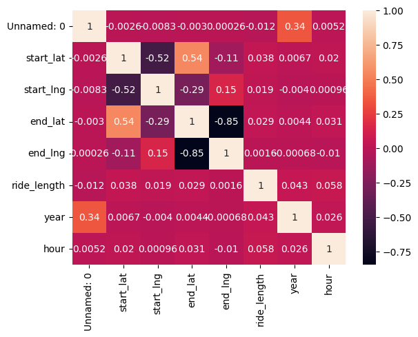

```python
sns.heatmap(df.corr(), annot=True)
```